# DownsideRisk

```
[*********************100%***********************]  1 of 1 completed
[*********************100%***********************]  1 of 1 completed
[*********************100%***********************]  1 of 1 completed
[*********************100%***********************]  1 of 1 completed
```

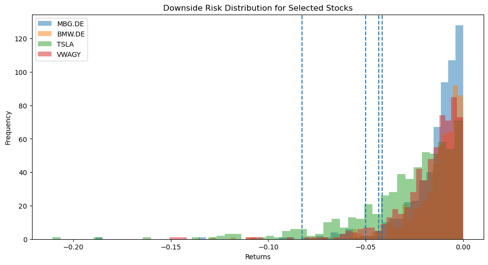

```
Downside Risk Metrics:
        Downside Risk (Semi-Deviation)  Value at Risk (VaR 95%)  \
MBG.DE                        0.017303                -0.043373
BMW.DE                        0.015212                -0.041660
TSLA                          0.027193                -0.082720
VWAGY                         0.018091                -0.050077

        Conditional VaR (CVaR 95%)
MBG.DE                   -0.069684
BMW.DE                   -0.060911
TSLA                     -0.109988
VWAGY                    -0.072913
```

```python
import yfinance as yf
import numpy as np
import pandas as pd
import matplotlib.pyplot as plt

# Step 1: Define stocks to compare
stocks = ["MBG.DE", "BMW.DE", "TSLA", "VWAGY"]  # Mercedes-Benz, BMW, Tesla, Volkswagen
start_date = "2020-02-17"
end_date = "2025-02-17"

# Step 2: Fetch data from Yahoo Finance
data = {}
for stock in stocks:
    df = yf.download(stock, start=start_date, end=end_date)["Adj Close"]
    data[stock] = df

# Convert to DataFrame
price_data = pd.DataFrame(data)

# Step 3: Compute daily returns (Fix: Drop NaN before calculating percentage change)
returns_data = price_data.dropna().pct_change(fill_method=None)

# Step 4: Calculate downside risk metrics
risk_metrics = {}
for stock in stocks:
    returns = returns_data[stock].dropna()
    downside_returns = returns[returns < 0]

    downside_deviation = np.std(downside_returns)
    var_95 = np.percentile(downside_returns, 5)  # 5th percentile
    cvar_95 = downside_returns[downside_returns <= var_95].mean()  # CVaR (expected shortfall)

    risk_metrics[stock] = {
        "Downside Risk (Semi-Deviation)": downside_deviation,
        "Value at Risk (VaR 95%)": var_95,
        "Conditional VaR (CVaR 95%)": cvar_95
    }

# Convert to DataFrame for display
risk_df = pd.DataFrame(risk_metrics).T

# Step 5: Plot histograms for downside returns
plt.figure(figsize=(12, 6))
for stock in stocks:
    downside_returns = returns_data[stock][returns_data[stock] < 0]
    plt.hist(downside_returns, bins=50, alpha=0.5, label=stock)
    plt.axvline(np.percentile(downside_returns, 5), linestyle='dashed')

plt.title("Downside Risk Distribution for Selected Stocks")
plt.xlabel("Returns")
plt.ylabel("Frequency")
plt.legend()
plt.show()

# Step 6: Display results (Fix: Use print instead of display_dataframe_to_user)
print("\nDownside Risk Metrics:")
print(risk_df)

# Optionally save results to a CSV file
risk_df.to_csv("downside_risk_metrics.csv")
```

Tesla (TSLA) is the riskiest stock

Highest downside deviation (0.0272 or 2.72%) → More volatile on the downside. Highest VaR (-8.27%) → Worst expected daily loss is 8.27%. Highest CVaR (-10.99%) → If losses exceed 8.27%, the average loss is 10.99%. Implication: Tesla experiences larger swings and greater downside risk than others. BMW (BMW.DE) is the least risky

Lowest downside deviation (0.0152 or 1.52%) → Less volatile negative returns. Lowest VaR (-4.17%) → On a bad day, loss should not exceed 4.17%. Lowest CVaR (-6.09%) → Extreme losses beyond VaR are also lower. Implication: BMW is more stable with less downside risk. Volkswagen (VWAGY) & Mercedes-Benz (MBG.DE) show moderate risk

VWAGY has slightly higher downside deviation than MBG.DE. Both have similar CVaR values (~-7%), meaning their extreme downside risks are comparable. Implication: These stocks carry moderate risk, making them a balanced choice. Tesla (TSLA): High volatility, high risk. Best for aggressive investors/traders. BMW (BMW.DE): Lowest downside risk. Best for conservative investors. Mercedes-Benz & Volkswagen: Moderate risk, stable choice